# Building Features, Watching What Happens

## Part 5: Transforming features

### 5A: Logs, for skewed predictors

Many urban variables are skewed: a few tracts have huge values, and most have small ones. Income, density, and counts are typical. A log compresses the long tail, so a model can use the difference between 1 and 10 as well as the difference between 100 and 1,000.

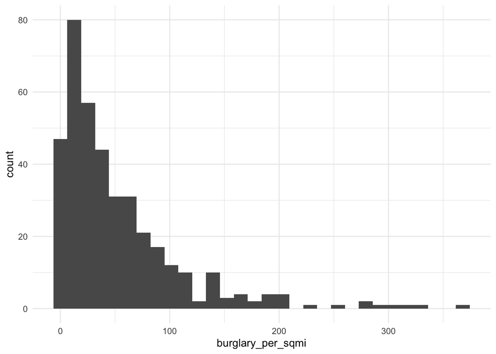

```r
ggplot(tracts, aes(x = burglary_per_sqmi)) + geom_histogram(bins = 30) + theme_minimal()
```

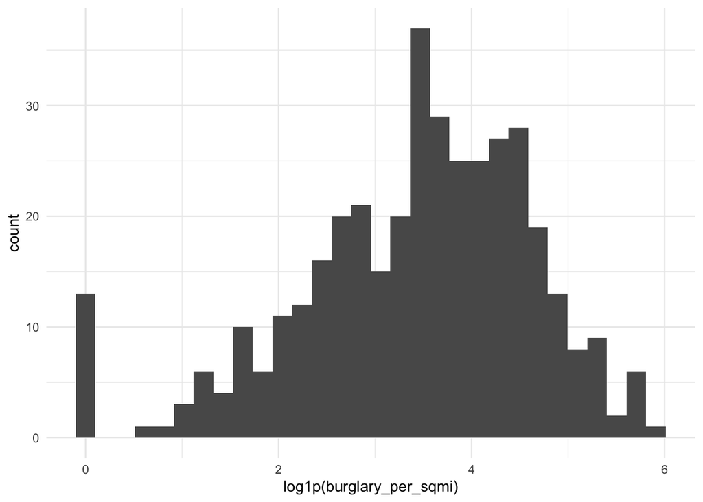

```r
ggplot(tracts, aes(x = log1p(burglary_per_sqmi))) + geom_histogram(bins = 30) + theme_minimal()
```

### 5B: Squared terms, for curves

If your scatterplot bends (rising and then flattening, or falling and then rising), a squared term lets the line curve. Write it with `I()`, which tells R to do the arithmetic rather than read `^` as formula syntax.

```r
m_sq <- lm(y ~ dist_ch_mi + I(dist_ch_mi^2), data = tracts)
summary(m_sq)
```

```
Call:
lm(formula = y ~ dist_ch_mi + I(dist_ch_mi^2), data = tracts)

Residuals:
    Min      1Q  Median      3Q     Max
-27.969  -8.586  -0.840   7.851  43.302

Coefficients:
                Estimate Std. Error t value Pr(>|t|)
(Intercept)     45.74304    1.78017  25.696  < 2e-16 ***
dist_ch_mi      -4.08558    0.64524  -6.332 6.75e-10 ***
I(dist_ch_mi^2)  0.08658    0.04850   1.785    0.075 .
---
Signif. codes:  0 '***' 0.001 '**' 0.01 '*' 0.05 '.' 0.1 ' ' 1

Residual standard error: 12.91 on 385 degrees of freedom
Multiple R-squared:  0.3795,    Adjusted R-squared:  0.3762
F-statistic: 117.7 on 2 and 385 DF,  p-value: < 2.2e-16
```

**Reading the coefficient:** you can’t read either coefficient alone anymore. The effect of X depends on where you are along X. A positive linear term with a negative squared term means Y rises with X and then levels off or turns down. Plot the fitted curve to see it:

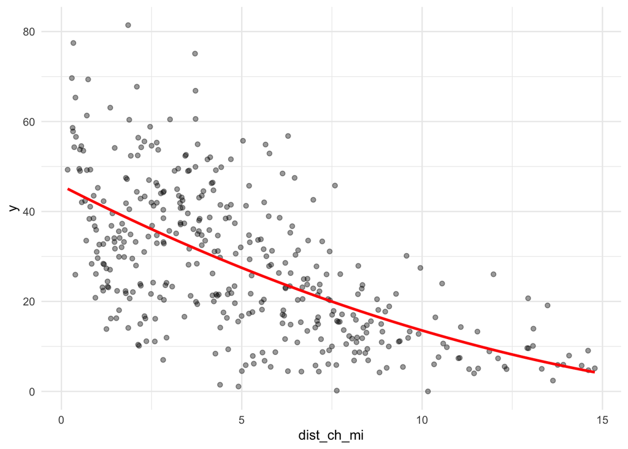

```r
ggplot(tracts, aes(x = dist_ch_mi, y = y)) +
  geom_point(alpha = 0.4) +
  geom_smooth(method = "lm", formula = y ~ x + I(x^2), se = FALSE, color = "red") +
  theme_minimal()
```

### 5C: Categorical variables

Sometimes a number works better as groups, either because the relationship isn’t smooth or because the categories are meaningful. You can make categories from any variable with `case_when()` or `cut()`, and then make sure R treats them as a **factor**.

```r
tracts <- tracts %>%
  mutate(
    ring = case_when(
      dist_ch_mi < 2 ~ "Core",
      dist_ch_mi < 5 ~ "Inner",
      TRUE           ~ "Outer"
    ),
    ring = factor(ring, levels = c("Core", "Inner", "Outer"))
  )

tracts %>% st_drop_geometry() %>% count(ring)
```

```
   ring   n
1  Core  80
2 Inner 136
3 Outer 172
```

```r
m_cat <- lm(y ~ ring, data = tracts)
summary(m_cat)
```

```
Call:
lm(formula = y ~ ring, data = tracts)

Residuals:
    Min      1Q  Median      3Q     Max
-33.837 -10.429  -1.548   8.576  42.791

Coefficients:
            Estimate Std. Error t value Pr(>|t|)
(Intercept)   38.635      1.523  25.368   <2e-16 ***
ringInner     -3.710      1.919  -1.933   0.0539 .
ringOuter    -20.431      1.843 -11.083   <2e-16 ***
---
Signif. codes:  0 '***' 0.001 '**' 0.01 '*' 0.05 '.' 0.1 ' ' 1

Residual standard error: 13.62 on 385 degrees of freedom
Multiple R-squared:  0.3097,    Adjusted R-squared:  0.3061
F-statistic: 86.35 on 2 and 385 DF,  p-value: < 2.2e-16
```

**Reading the coefficients:** R turns a factor with k categories into k − 1 dummy variables. The category left out is the **reference level** (here, “Core,” the first level). Each coefficient is the **difference from the reference**: `ringOuter` is how much higher or lower predicted Y is in outer tracts *compared to core tracts*, holding everything else in the model constant. To change the reference, use `relevel(ring, ref = "Outer")`.

### 5D: Your turn

Try **at least one of each**: a log, a squared term, and a categorical variable. Choose which variables to transform based on your plots, not at random. Log each model.

```r
# Log
f_log <- y ~ log1p(median_incomeE) + median_ageE +
  renter_pct + dist_bus_stop_mi

model_log <- model_log %>%
  add_row(
    model = "m5",
    added = "Log of median income",
    cv_rmse = cv_rmse(f_log, tracts),
    notes = "Tests whether a log transformation of income improves prediction"
  )


# Squared term
f_sq <- y ~ median_incomeE + median_ageE + renter_pct +
  dist_bus_stop_mi + I(dist_bus_stop_mi^2)

model_log <- model_log %>%
  add_row(
    model = "m6",
    added = "Squared bus-stop distance",
    cv_rmse = cv_rmse(f_sq, tracts),
    notes = "Tests for a curved relationship between transit distance and vehicle ownership"
  )


# Categorical
tracts <- tracts %>%
  mutate(
    ring = case_when(
      dist_ch_mi < 2 ~ "Core",
      dist_ch_mi < 5 ~ "Inner",
      TRUE ~ "Outer"
    ),
    ring = factor(ring, levels = c("Core", "Inner", "Outer"))
  )

tracts %>% st_drop_geometry() %>% count(ring)
```

```
   ring   n
1  Core  80
2 Inner 136
3 Outer 172
```

```r
f_cat <- y ~ median_incomeE + median_ageE + renter_pct +
  ring + dist_bus_stop_mi

model_log <- model_log %>%
  add_row(
    model = "m7",
    added = "Categorical City Hall distance",
    cv_rmse = cv_rmse(f_cat, tracts),
    notes = "Tests whether core, inner, and outer areas differ in vehicle ownership"
  )

model_log
```

```
# A tibble: 7 × 4
  model added                          cv_rmse notes
  <chr> <chr>                            <dbl> <chr>
1 m1    ACS baseline                      12.4 Baseline model with income, age,…
2 m2    Bus stop count                    12.5 Tests whether the number of bus …
3 m3    Bus-stop density                  11.0 Adjusts for tract area to measur…
4 m4    Distance to nearest bus stop      12.0 Tests whether proximity to trans…
5 m5    Log of median income              11.7 Tests whether a log transformati…
6 m6    Squared bus-stop distance         11.8 Tests for a curved relationship …
7 m7    Categorical City Hall distance    10.4 Tests whether core, inner, and o…
```

**Answer:** Which transformation helped most? For your categorical variable, write one sentence reading one of its coefficients correctly, naming the reference level.

## Part 6: Your final model

Combine the features and transformations that earned their place, **judged by CV RMSE, not p-values.**

```r
f_final <- y ~ log1p(median_incomeE) +
  median_ageE + renter_pct +
  ring + dist_bus_stop_mi

m_final <- lm(f_final, data = tracts)
summary(m_final)
```

```
Call:
lm(formula = f_final, data = tracts)

Residuals:
    Min      1Q  Median      3Q     Max
-25.992  -6.574  -0.644   5.920  32.170

Coefficients:
                       Estimate Std. Error t value Pr(>|t|)
(Intercept)           196.14251   16.13308  12.158  < 2e-16 ***
log1p(median_incomeE) -15.18059    1.33284 -11.390  < 2e-16 ***
median_ageE             0.03948    0.07353   0.537    0.592
renter_pct              0.22917    0.03145   7.287 1.84e-12 ***
ringInner             -10.80449    1.74866  -6.179 1.66e-09 ***
ringOuter             -19.87784    1.80576 -11.008  < 2e-16 ***
dist_bus_stop_mi       -8.42589    6.23703  -1.351    0.178
---
Signif. codes:  0 '***' 0.001 '**' 0.01 '*' 0.05 '.' 0.1 ' ' 1

Residual standard error: 10.08 on 381 degrees of freedom
Multiple R-squared:  0.626, Adjusted R-squared:  0.6201
F-statistic: 106.3 on 6 and 381 DF,  p-value: < 2.2e-16
```

```r
model_log <- model_log %>%
  add_row(model = "final", added = "Log income + City Hall distance categories + bus-stop distance",
          cv_rmse = cv_rmse(f_final, tracts),
          notes = "Combines the best-performing transformations and spatial predictors")
#getting rid of the duplicated again?
model_log <- model_log %>%
  distinct(model, .keep_all = TRUE)


model_log
```

```
# A tibble: 8 × 4
  model added                                                      cv_rmse notes
  <chr> <chr>                                                        <dbl> <chr>
1 m1    ACS baseline                                                  12.4 Base…
2 m2    Bus stop count                                                12.5 Test…
3 m3    Bus-stop density                                              11.0 Adju…
4 m4    Distance to nearest bus stop                                  12.0 Test…
5 m5    Log of median income                                          11.7 Test…
6 m6    Squared bus-stop distance                                     11.8 Test…
7 m7    Categorical City Hall distance                                10.4 Test…
8 final Log income + City Hall distance categories + bus-stop dis…    10.1 Comb…
```

### Where is the final model wrong?

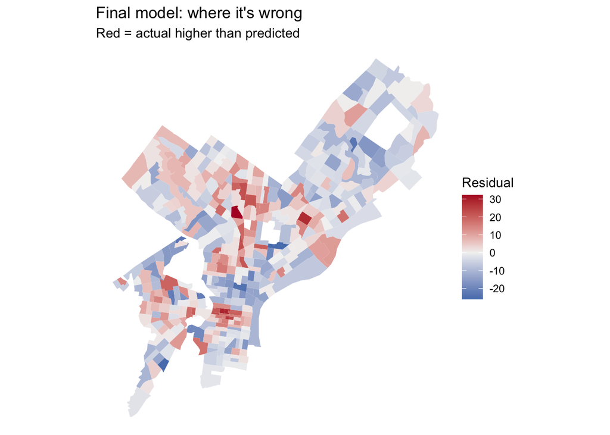

```r
tracts <- tracts %>% mutate(resid_final = residuals(m_final))

ggplot(tracts) +
  geom_sf(aes(fill = resid_final), color = NA) +
  scale_fill_gradient2(low = "#2166ac", mid = "grey95", high = "#b2182b", midpoint = 0) +
  theme_void() +
  labs(title = "Final model: where it's wrong",
       subtitle = "Red = actual higher than predicted",
       fill = "Residual")
```

Put your two residual maps side by side, or put them next to each other in the rendered document. Did the clusters from Part 2C shrink? Where did they stay?

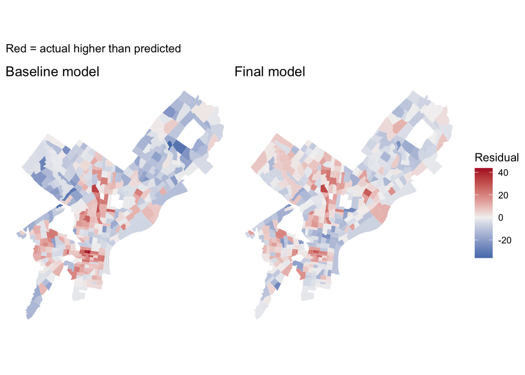

```r
library(patchwork)

lims <- range(c(tracts$resid_m1, tracts$resid_final))

map_fun <- function(var, ttl) {
  ggplot(tracts) +
    geom_sf(aes(fill = {{ var }}), color = NA) +
    scale_fill_gradient2(low = "#2166ac", mid = "grey95", high = "#b2182b",
                         midpoint = 0, limits = lims) +
    theme_void() +
    labs(title = ttl, fill = "Residual")
}

(map_fun(resid_m1, "Baseline model") | map_fun(resid_final, "Final model")) +
  plot_layout(guides = "collect") +
  plot_annotation(subtitle = "Red = actual higher than predicted")
```

### Are the biggest misses in the least reliable tracts?

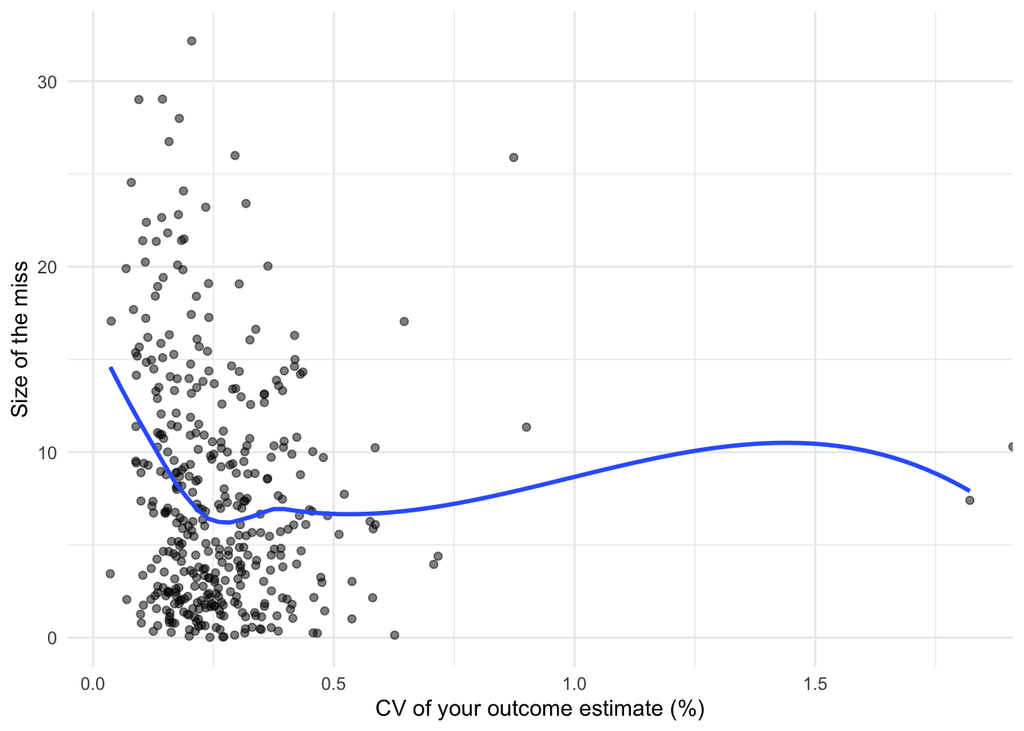

```r
ggplot(tracts, aes(x = y_cv, y = abs(resid_final))) +
  geom_point(alpha = 0.5) +
  geom_smooth(se = FALSE) +
  labs(x = "CV of your outcome estimate (%)", y = "Size of the miss") +
  theme_minimal()
```